# CCTR691 Single Cell RNASeq Lab

Paulette Omeaku

September 25, 2025

# Single Cell RNASeq Lab

### Primary Goal:

> Perform QC analysis on a single cell data set using the R Seurat package.

### Instructions:

Use the Athena terminal to set up your lab directory and obtain needed files.

*In the event the cluster is down, use Canvas to download the needed files into a directory on your laptop and complete the lab locally.*

To get help using any command, type “?” followed by the command to see the documentation. E.g. “?plot”

```bash
# create and navigate into a new directory for this lab
mkdir scRNASeq
cd scRNASeq

# Copy feature count directory
cp -r /lustre/home/git_repos/CCTR691/scRNASeq/filtered_feature_bc_matrix_WHIM2_106361_HumanOnly .

# Copy supporting files
cp /lustre/home/git_repos/CCTR691/scRNASeq/MitoCodingGenes13_human.txt .
cp /lustre/home/git_repos/CCTR691/scRNASeq/UCD52CR_107086_web_summary.html .
```

## Submission:

This Rmd file and its associated HTML output will be submitted to GitHub. The GitHub URL will be submitted to Canvas.

### Section 1: Exploring 10X HTML QC Files

The majority of this lab will be completed in the Rmarkdown template EXCEPT this first section.

Download the “UCD52CR_107086_web_summary.html” file to your laptop and open it in a web browser, then answer the first set of questions in the RMarkdown template.

### Questions 1 and 2

Q1) Was this sample aligned to a SINGLE or MULTIPLE genomes?

Q2) With the knowledge that we expect about 5000 cells from this sample, list at least 2 red flags identified by this report. Be sure to explore both tabs.

> <1. we counted about 5,000 but there is oveer 17,000. Meaning there needs to be a quality check because this number is way too high. 2. The TSNE is not breaking out in discrete group but showing up more uniformly>

## Section 2: QC analysis and Dead Cell Removal using the Seruat package in R

Follow the instructions and code to remove dead cells, generate violin plots, cluster, and create tSNE plots of the sample data.

The sample data you are using is publicly available on GEO (Gene Expression Omnibus) in the Series GSE174391, only it is merged with other samples. For this lab I am providing you with the single WHIM2 PDX sample that has already had the mouse cells removed (so you only have human data).

Follow the steps below and answer the questions. This lab is based off of, but not exactly the same as, the Seurat introductory tutorial. Feel free to [explore that tutorial for more in-depth information](https://satijalab.org/seurat/articles/pbmc3k_tutorial.html).

### Set working directory and load libraries

- Use the File navigation pane to navigate to your working lab directory that contains this and the other files.
- Select the blue gear and click “Set As Working Directory”.
- Look in the console for a setwd() command. COPY the path it uses to the code block below to set your working directory globally for this workbook.
- Click the green “play” button to execute the code chunk.

```r
knitr::opts_knit$set(root.dir = "/lustre/home/omeakupb/git_repos/CCTR691/CCTR691_scRNASeq")
```

```r
#install.packages(c("SeuratObject","Matrix","dplyr","ggplot2"))
```

```r
#install.packages("Seurat")
```

```r
#install.packages("Seurat")
```

```r
#install.packages("pak")
#pak::pak("Seurat")
```

```r
library(Seurat)
library(dplyr)
library(knitr)
```

### Load dataset, initilize Seurat Object and View object properties

```r
#Load the WHIM2 dataset into Seurat:
whim.data <- Read10X(data.dir = "./filtered_feature_bc_matrix_WHIM2_106361_HumanOnly")

#Initialize the Seruat Object:
whim <- CreateSeuratObject(counts = whim.data, project = "whim2", min.cells = 3, min.features = 200)

#View a summary of the object:
whim
```

```
## An object of class Seurat
## 19612 features across 2575 samples within 1 assay
## Active assay: RNA (19612 features, 0 variable features)
##  1 layer present: counts
```

In the environment tab of the RStudio interface, click on the “whim” object to expand and explore it. Look for the “meta.data” section. This is the most important section as it is where your new annotations are stored, and it tells you the name of annotations added by clustering and other processing.

### Questions 3 and 4

Q3) What metadata elements are listed in this section?

> <original identifier, RNA count, RNA feature count>

Q4) I told you this is 1 PDX sample, but the summary of the Seurat object says differently. How many samples does this object have? What is this actually telling you? What does the 19,612 number represent?

> <19,612 features number of gene names; 2,575 are the number cells >

### Assess Percentage of Mitochondrial Gene Expression

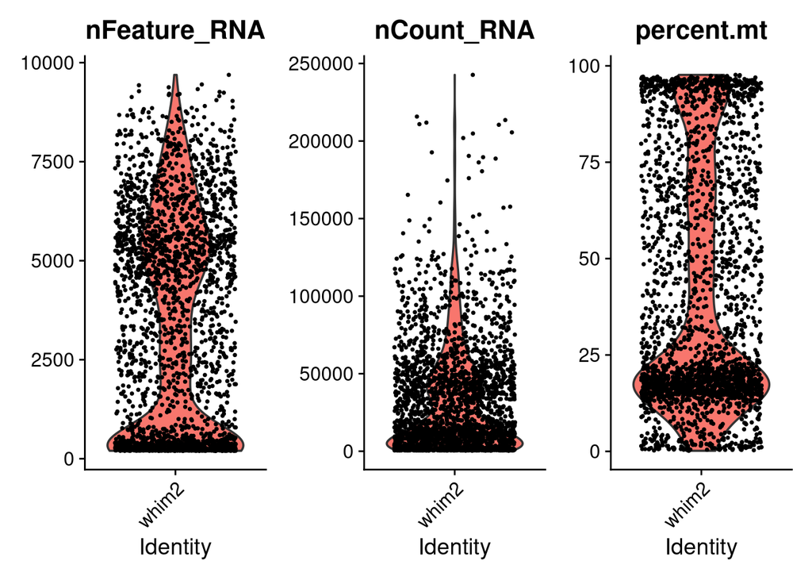

```r
# Load in the mitochondrial gene IDs:
mitogene_ids <- read.delim("./MitoCodingGenes13_human.txt", header = FALSE, stringsAsFactors = FALSE)[[1]]

# Add the percentage of mito expression as an annotation to your Seurat object:
whim[["percent.mt"]] <- PercentageFeatureSet(whim, features = mitogene_ids)

# Create a Violin plot of the mito expression, nFeature and nCount data
# These last 2 were already in the dataset by default, so we didn’t need to add them.
VlnPlot(whim, features = c("nFeature_RNA", "nCount_RNA", "percent.mt"), ncol = 3, pt.size = .4)
```

### Question 5

Q5) What is a reasonable filtering criteria for the percent of mitochondria expression?

Sub set your cells to remove those that do not pass your mitochondrial cutoff. Make sure to replace the “ADD_YOUR_CUTOFF_HERE” with the appropriate expression (i.e. “> x” or “< x” where “x” is the threshold you specified in Q5 - do not include the quotation marks).

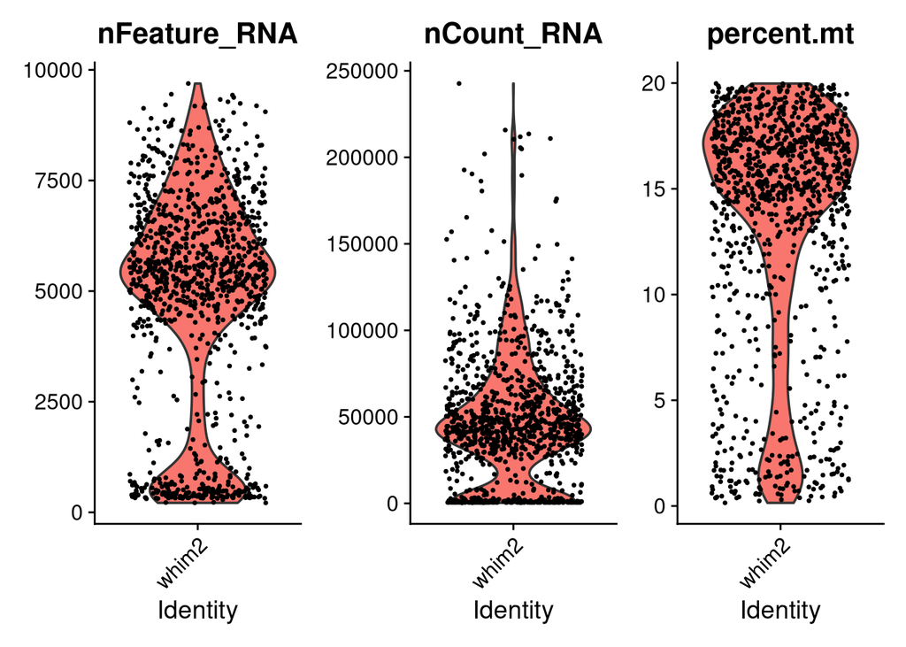

```r
# subset the seurat object for only cells passing your cutoff and print out the new violin plot
whim_filtered <- subset(whim, subset = percent.mt <20)

# print new violin plot
VlnPlot(whim_filtered, features = c("nFeature_RNA", "nCount_RNA", "percent.mt"), ncol = 3, pt.size = .4)
```

Note that we now have two (2) Seurat data sets, “whim” contains the full unfiltered dataset, and “whim_filtered” contains the filtered dataset.

### Questions 6 and 7

Q6) How many cells survived the filtering? Print out the new “whim_filtered” object to figure this out.

```r
whim_filtered
```

```
## An object of class Seurat
## 19612 features across 1097 samples within 1 assay
## Active assay: RNA (19612 features, 0 variable features)
##  1 layer present: counts
```

> <1097 cells survived>

Q7) Compare the 2 plots, before and after. What can you conclude about the cells that did not make the mitochondrial cutoff in terms of nFeature and nCount? If you want to print both plots in the same R code chunk to compare more easily you can do that.

> <The cells that did not survive were likely of poor quality (low feature and RNA counts and high mitochondrial numbers or expression. >

You can continue to filter on nFeature and nCount, and I generally do, but for the purposes of this lab we will leave the dataset as-is and move on to normalization and clustering.

## Section 3: Normalization, Top Variable Features, PCA, Clustering, and Visualization

Before we can cluster the data and create those cool tSNE and UMAP visualizations, we need to normalize and scale the data, and run a PCA analysis. However, this can take a long time if we use all genes. Thus, we will reduce the set used to the most variable genes (don’t worry, the rest are still there).

### Identify the top variable genes

```r
# Using the “whim_filtered” Seurat data set, normalize the data.
whim_filtered <- NormalizeData(whim_filtered)
```

```
## Normalizing layer: counts
```

```r
# Before creating the visualizations, we need to reduce the dataset down to only
# those genes with the most variance.  These will be our top 2000 most variable features.
whim_filtered <- FindVariableFeatures(whim_filtered, selection.method = "vst", nfeatures = 2000)
```

```
## Finding variable features for layer counts
```

```r
top10 <- head(VariableFeatures(whim_filtered), 10)

# Plot the top10 most variable genes as a scatter plot and mark the top 10
plot1 <- VariableFeaturePlot(whim_filtered)
plot2 <- LabelPoints(plot = plot1, points = top10, repel = TRUE)
```

```
## When using repel, set xnudge and ynudge to 0 for optimal results
```

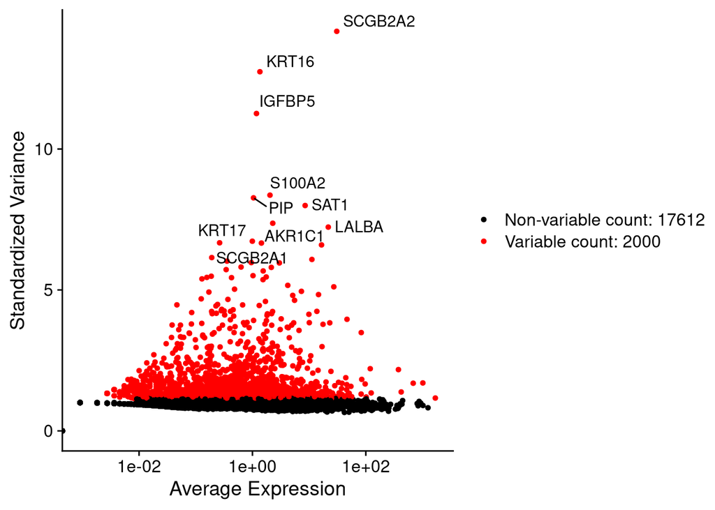

```r
plot2
```

### Question 8

Q8) Which gene is the most variable?

### Scaling and PCA Analysis

What does scaling do? * Shifts the expression of each gene, so that the mean expression across cells is 0 * Scales the expression of each gene, so that the variance across cells is 1 * This step gives equal weight in downstream analyses, so that highly-expressed genes do not dominate

Principle Component Analysis is a dimension reduction technique that transforms large data sets with a lot of dimensions into a data set with fewer dimensions, but still retains the majority of the information present, such as variability, in the initial data set. In single cell RNASeq it is used as a first step to identify the most informative principle components that should be used for data visualization by UMAP and tSNE.

```r
# scale data
whim_filtered <- ScaleData(whim_filtered)
# run PCA
whim_filtered <- RunPCA(whim_filtered, features = VariableFeatures(object = whim_filtered))
```

```
## PC_ 1
## Positive:  KIFC1, CENPF, UBE2T, H2AFV, TMEM106C, GMNN, HIST1H4C, ASPM, SIVA1, ESCO2
##     TUBA1B, PSIP1, HACD3, NASP, LBR, ANLN, RRM2, MKI67, NUSAP1, DEK
##     KIF23, STMN1, ARL6IP1, TPX2, GTSE1, MT-CO2, ANP32E, TUBG1, C21orf58, MIS18BP1
## Negative:  MGP, SCGB3A1, SCGB2A2, LBH, MTRNR2L6, PHLDA1, PLCG2, EMP1, CX3CL1, PIP
##     RNASE7, KRTAP5-8, PXDC1, DNAH11, CA9, ZG16B, SCGB2A1, FMO2, KRT16, TNFSF15
##     LEMD1, TNFSF10, SYCE1L, LINC02613, C5orf46, IGFBP5, CHST9, RASD1, DHRS3, MIR210HG
## PC_ 2
## Positive:  H2AFZ, UBE2C, TOP2A, TUBA1B, UBE2S, NUSAP1, PBK, CCNB1, MKI67, PTTG1
##     STMN1, CENPF, UBE2T, TPX2, HMGB1, CENPA, BIRC5, HMMR, RRM2, HMGB2
##     NUF2, CDCA8, CCNA2, MAD2L1, CDK1, ASPM, DLGAP5, AURKB, AURKA, PLK1
## Negative:  IER3, NEAT1, NDRG1, KLF6, CEBPD, AHNAK, MALAT1, VEGFA, SAT1, PNRC1
##     COL6A2, P4HA2, LGALS3, TFCP2L1, FBXO32, ELF3, USP53, EGLN3, ERO1A, RRAGD
##     BNIP3L, DUSP4, PFKP, FZD8, OLMALINC, ATF3, BHLHE40, ANKRD37, SLC2A1, KCNQ1OT1
## PC_ 3
## Positive:  TOP2A, HMGB2, DLGAP5, NUSAP1, MKI67, CENPA, CCNA2, TPX2, PFKP, UBE2C
##     HMMR, KIF4A, NUF2, CAMK1D, AURKB, HIST1H1B, NDRG1, ERO1A, ASPM, CENPE
##     PIF1, CENPF, GTSE1, CDKN3, NEK2, KIFC1, KNL1, NDC80, CDK1, KIF14
## Negative:  SELENBP1, AZGP1, PAK1IP1, OAZ3, NES, EEF1E1, MT-CO2, SRM, LY6E, IFITM3
##     KRTAP5-10, CITED4, HACD3, ROPN1, NOP16, MNX1-AS1, NDUFAF4, NME1, NFIA, ZG16B
##     ATP5PB, PLA2R1, FKBP1A, NPM3, E2F1, TSC22D3, MTX1, SDF2L1, STAC2, RCSD1
## PC_ 4
## Positive:  EGLN3, PFKP, ANGPTL4, NRN1, CAMK1D, IGFBP5, SLC16A3, LOX, SLC2A1, P4HA1
##     NDRG1, CHI3L1, ERO1A, FZD8, AKR1C2, VEGFA, STC1, FAM162A, CA9, EGFR
##     COL23A1, NCAN, BNIP3, AKR1C3, ADM, AL133453.1, SCGB2A2, WDR54, CD5L, STC2
## Negative:  AQP3, KRT14, KLK7, COL9A3, FAM3D, CCL28, TPT1-AS1, ANXA1, SLC34A2, RAB11FIP1
##     KLK10, CDK6, EMP1, KRT16, S100P, LBH, INHBA, SULF2, ADD3, KLF6
##     NCCRP1, MAP3K8, CXCL17, ITPKC, KLF5, GABRP, KLK6, CEACAM1, BTG2, CALML5
## PC_ 5
## Positive:  ARL6IP1, LGALS1, PTTG1, S100A16, CDC20, CCNB2, CCNB1, NMU, S100A10, CDKN3
##     HMGN2, HMGB3, H2AFV, ANXA3, SNRPG, KLK5, TUBA1A, TMSB4X, KRT14, PSMA7
##     JPT1, MIEN1, NQO1, LCN2, HIST3H2A, ANXA2, KLK8, TAGLN2, LGALS3, KLK6
## Negative:  MCM4, HELLS, DTL, MCM10, XRCC2, ATAD2, MCM3, E2F7, HSD17B7, FAM111B
##     MSH6, MCM6, CLSPN, CCNE2, HIST1H1B, LDLR, AC092683.1, CCNE1, ESCO2, NCOA7
##     SMC1A, CDC6, NR4A2, OLMALINC, NEAT1, MMS22L, ARHGAP10, BRCA1, E2F1, FOSB
```

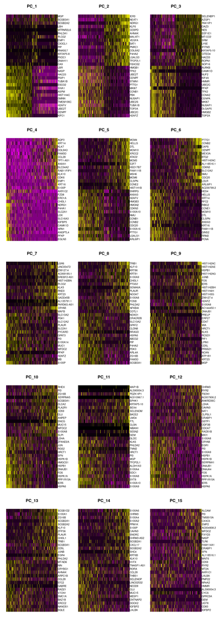

```r
# create heatmap
DimHeatmap(whim_filtered, dims = 1:15, cells = 500, balanced = TRUE)
```

### Question 9-11

Q9) What are the axes of each heatmap?

> <The x-axis represents cells, and the y-axis represents the top genes that contribute the most to each PC. Each heatmap shows how expression levels of these genes vary across the cells, and the color intensity shows scaled expression.>

Q10) How many cells are used in each heatmap?

> <500>

Q11) Describe what happens when the principal component (PC) number gets higher.

> <As the PC number increases, the heatmaps show less unique structure and more noise. The first few PCs capture the most significant variation in the data. There are clear gene expression patterns and separations between groups of cells.>

### Determining the optima number of Principle Components

To visualize single cell data we need to use enough PCs to represent the variability in the data without adding too much noise or having too little. An Elbow plot can help with this along with looking at the DimHeatmap plots. We need to pick a threshold close to the elbow in the plot. This indicates where not much more information is being added.  
For the plot generated by the command below it looks to be around 5; however, the default is usually 15, which is a good cutoff for most datasets.

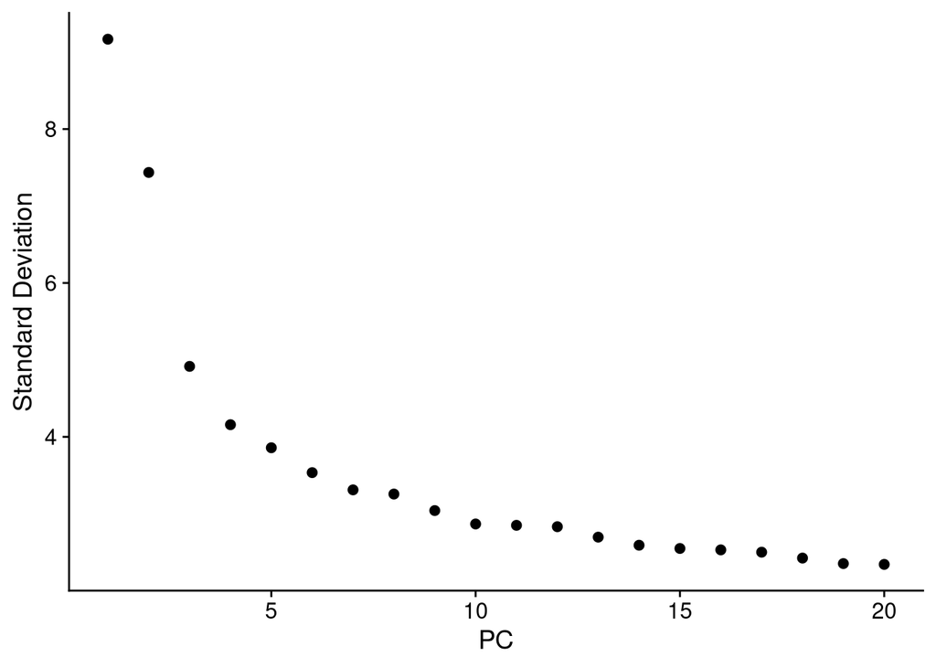

```r
# draw elbow plot
ElbowPlot(whim_filtered)
```

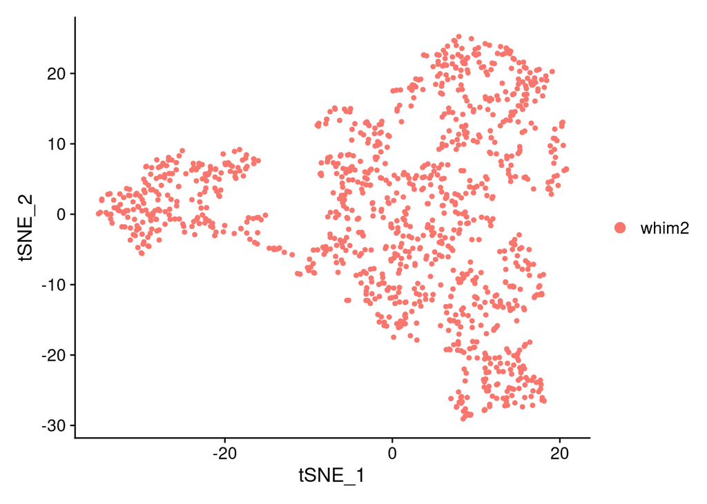

```r
#Create a tSNE plot using the first 5 dimensions.
whim_filtered <- RunTSNE(whim_filtered, dims = 1:5)
DimPlot(whim_filtered, reduction = "tsne")
```

```r
# add additional code here based on Question 12
```

### Question 12

Q12) In the code block above, copy the 2 lines of code that generated the tSNE plot to answer the following questions. Note I am expecting at least 4 plots.

What happens when you use fewer dimensions?

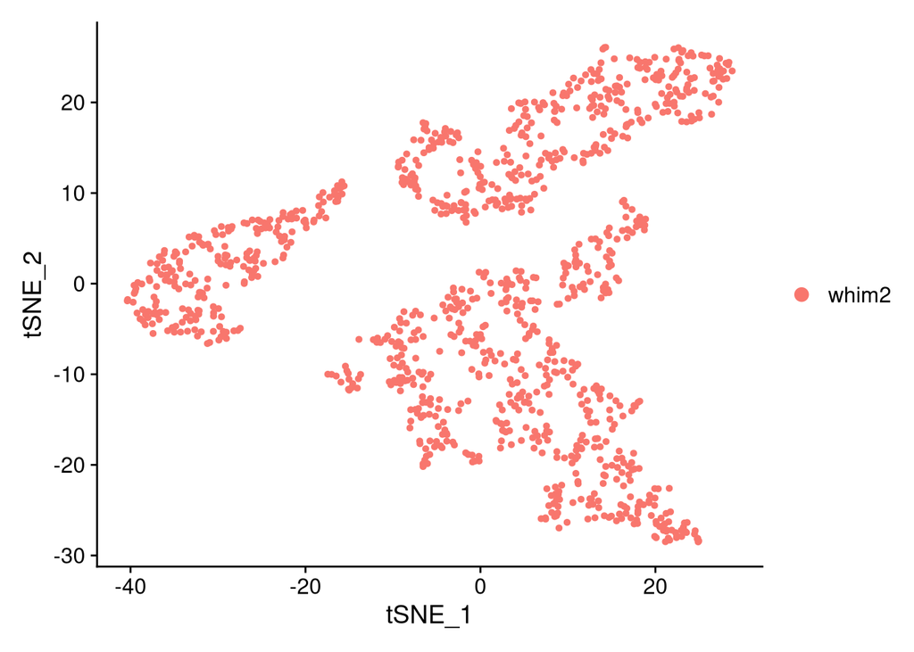

```r
whim_filtered <- RunTSNE(whim_filtered, dims = 1:2)
DimPlot(whim_filtered, reduction = "tsne")
```

> <The tSNE plot shows less of the variability in the dataset. The plot shows incomplete clusters and relies on a smaller portion of the total variance.>

How about only the first dimension?

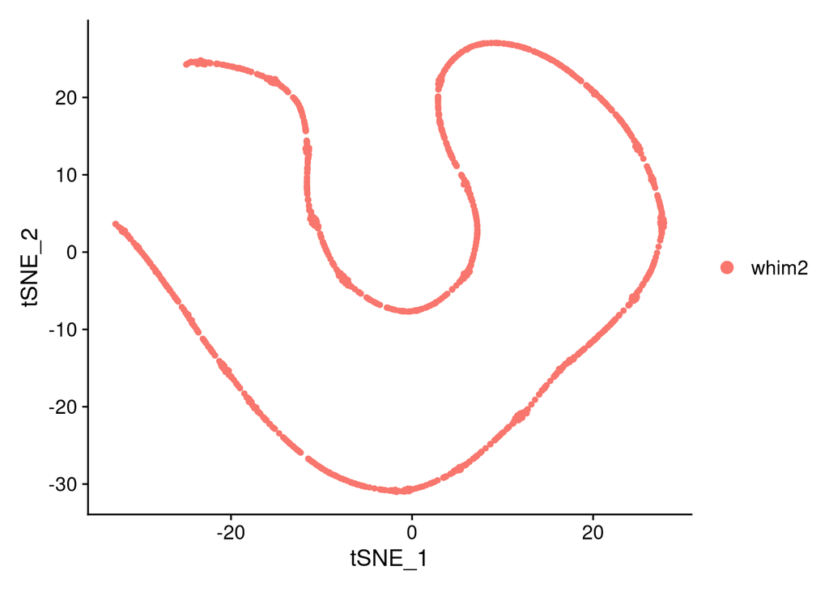

```r
whim_filtered <- RunTSNE(whim_filtered, dims = 1)
DimPlot(whim_filtered, reduction = "tsne")
```

> <Using the first PC drastically simplifies the data and becomes linear. There’s no clear way to define or see clustering>

What happens when you use more dimensions?

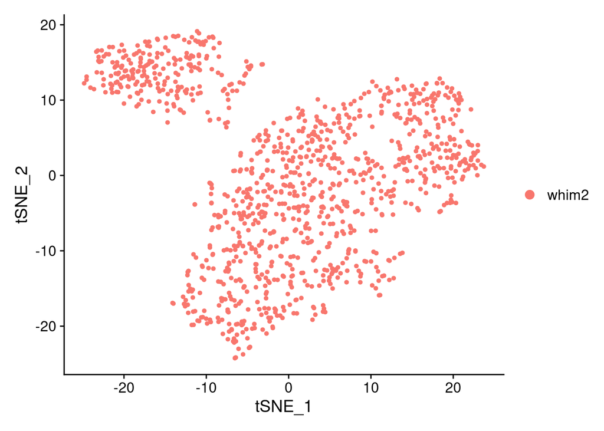

```r
whim_filtered <- RunTSNE(whim_filtered, dims = 1:15)
DimPlot(whim_filtered, reduction = "tsne")
```

> <The tSNE shows more variation and clearer structure in the data.>

### Gene Expression and Clustering

This flat pink plot is pretty boring. Let’s add some color by coloring each cell with the expression level of the 2 top most variable genes you identified in Q8.

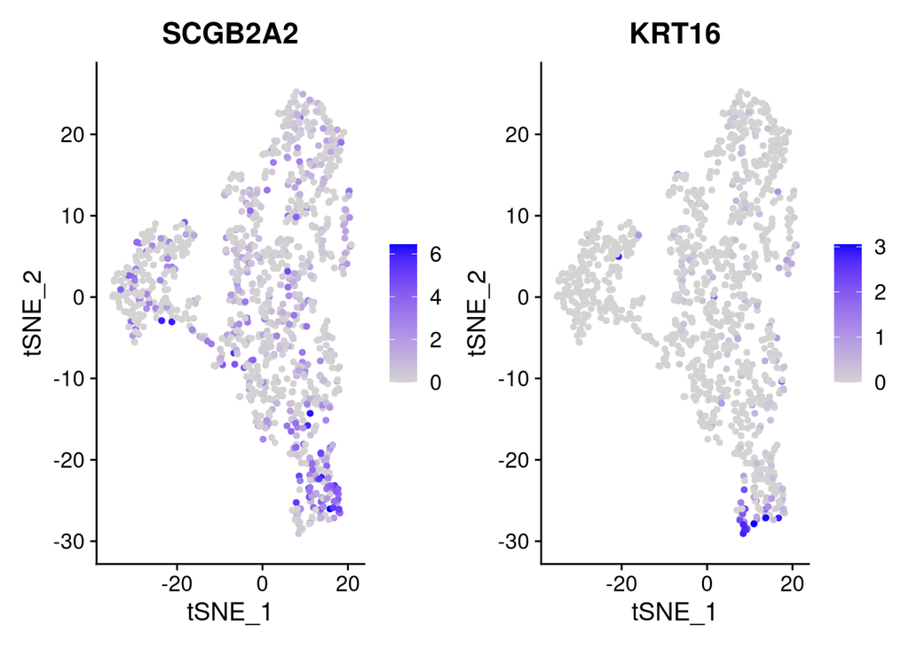

```r
# change dimensions back to 1:5
whim_filtered <- RunTSNE(whim_filtered, dims = 1:5)

# create the feature plot
FeaturePlot(whim_filtered, features = c("SCGB2A2", "KRT16"), reduction = "tsne")
```

You should get 2 plots with the most highly expressed gene grouped into a single location. This could be a cluster of cells with similar gene expression profiles. To find out, let’s cluster the dataset, and then color the tSNE plot by cluster.

```r
# find nearest neighbors and cluster cells
whim_filtered <- FindNeighbors(whim_filtered, dims = 1:5)
whim_filtered <- FindClusters(whim_filtered, resolution = 0.5)
```

```
## Modularity Optimizer version 1.3.0 by Ludo Waltman and Nees Jan van Eck
##
## Number of nodes: 1097
## Number of edges: 32721
##
## Running Louvain algorithm...
## Maximum modularity in 10 random starts: 0.8106
## Number of communities: 4
## Elapsed time: 0 seconds
```

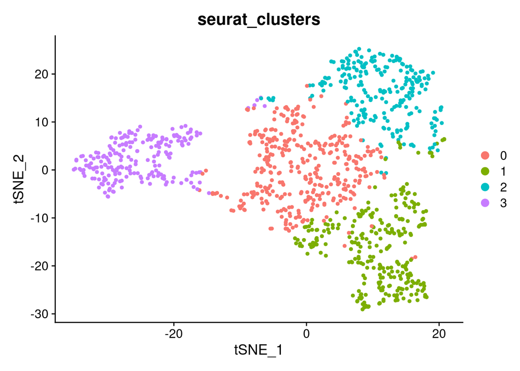

```r
# overlay cluster colors onto dim plot
DimPlot(whim_filtered, reduction = "tsne", group.by = "seurat_clusters")
```

### Question 13

Q13) Which cluster includes the 2 genes you plotted in Q11?

> <Cluster 1 (green) had the strongest expression for both SCGB2A2 and KRT16>

### Differential Gene Expression Analysis

Now we can explore each gene one at a time, which is not very efficient.  
Next we will run an all-by-all differential expression analysis to identify the top 20 gene markers for each cluster.

```r
# find marker genes for each cluster
whim_filtered.markers <- FindAllMarkers(whim_filtered, only.pos = TRUE, min.pct = 0.25, logfc.threshold = 0.25)
```

[output not shown]

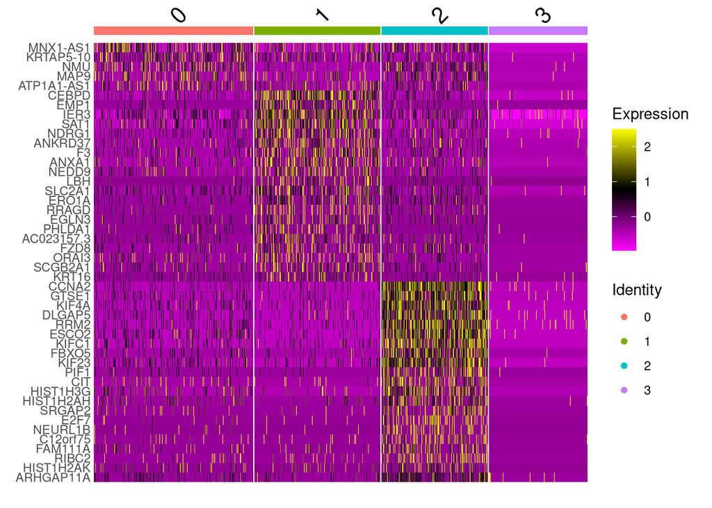

```r
# identify the top 20 marker genes for each cluster
top20 <- whim_filtered.markers %>% group_by(cluster) %>% top_n(n = 20, wt = avg_log2FC)

# plot marker gene expression for each cluster
DoHeatmap(whim_filtered, features = top20$gene)
```

### Question 14 and 15

Q14) What is the x-axis for in this plot?

> <The x-axis represents individual cells, grouped by their assigned Seurat clusters>

Q15) Which 2 clusters have the most distinct expression profile from the rest of the clusters?

> <Clusters 1 and 2 show the most distinct expression>

### Exporting DEG Results

Finally, let’s export your list of differential expressed genes to a text file.  
First filter base on significant p-value, then save to a file. Column explanations are as follows:

- **P_val:** the unadjusted p-value
- **avg_log2FC:** the average log2 fold change for this gene comparing cells in the active cluster to all other cells in the dataset.
- **Pct.1:** the percent of cells in the active cluster that express the given gene.
- **Pct.2:** the percent of all other cells that express this gene (used as the control condition).
- **P_val_adj:** the p-value adjusted for multiple testing correction.
- **Cluster:** the active cluster
- **Gene:** the gene ID

```r
# filter on adjusted pval
whim_filtered.markers <- whim_filtered.markers[whim_filtered.markers$p_val_adj <= 0.001,]

# save to a CSV file
write.csv(whim_filtered.markers, file="whim_filtered_SignificantMarkerGenes.csv", quote = FALSE)
```

### Question 16

Either through Athena, or by downloading this file, open the CSV file and answer the following question.

Q16) What is the log2FC of the top most variable gene you identified in Q8?

> <The log2 fold change of SCGB2A2 is 2.97, meaning there is a strong upregulation in Cluster 1 compared to all other clusters>

## Section 4: Save and upload via GitHub

Finally, save this file, then knit your HTML report for submission via GitHub.  
Go back to the Word document for github instructions!